# Tidy Data and Types

## Today’s Learning Goals

- Identify observations and variables in tidy data.
- Reshape data and construct dates for summaries and plots.
- Choose appropriate data classes and explain coercion.
- Report recent and frequent customer activity in Quarto.

## More About Quarto Docs - YAML

The header at the top of a Quarto document is coded in **YAML** (YAML Ain’t Markup Language).

```
---
title: "Exercise 4"
author: "Cameron Bale"
format: docx
---
```

## More About Quarto Docs - Quarto Best Practices

- Use `##` headings and `###` sub-headings to clearly identify sections.
- Code cells begin with `` ```{r} `` and end with `` ``` ``. Put code and `#` comments inside; write explanatory text outside.
- Use a separate code cell for every task so that output and text can be provided *in-line*.
- Produce bullet points using ‘-’.
- Identify `functions` and `data` with `s, *italics* with *s, and **bold** with **s.
- Quarto also has a visual editor.
- There are options, including running all previous code or a single code cell.
- After you render, **Always read the output.**

## Motivating Example

Patagonia wants to understand trends in customer purchase activity over time. The transaction file contains monthly purchase counts from January 2005 through December 2018. What measures would help tell that story?

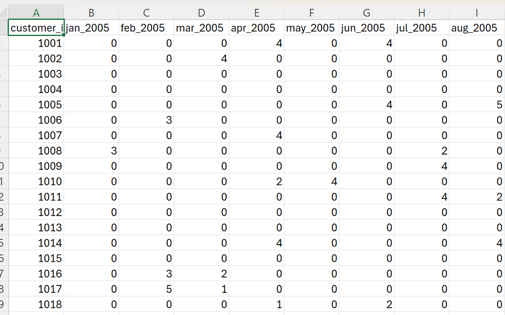

## This Data is Problematic!

The current format stores each month’s purchase counts in a separate column. A different arrangement would make some summaries easier to compute.

- How do we compute the total transactions per year?
- How do we compute the number of transactions for each customer?

Luckily, we can use some functions to `tidy` our data…

## Marketing Analytics Process

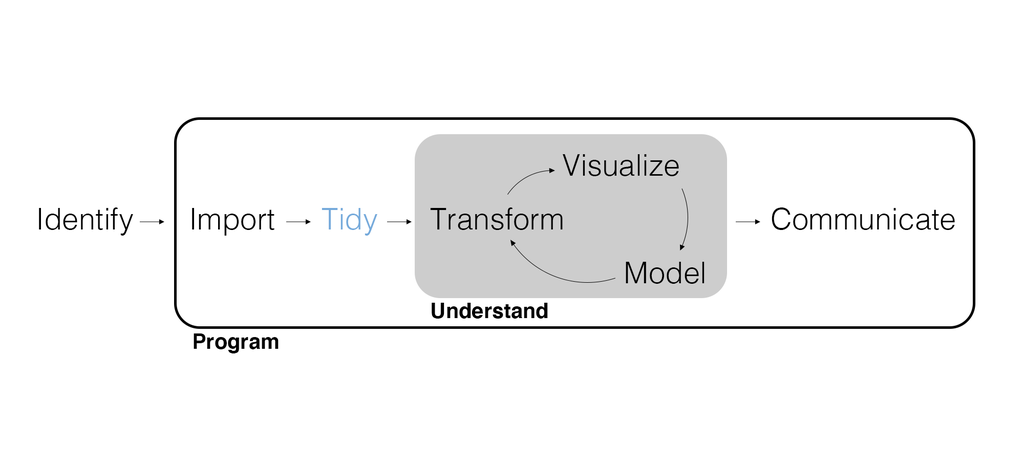

```r
library(tidyverse)
crm_data <- read_csv("customer_data.csv", show_col_types = FALSE) |>
  left_join(read_csv("store_transactions.csv", show_col_types = FALSE), join_by(customer_id))
```

## Data Structure and Summarizing

Task: compute the *total* transactions and *average transactions per month per customer* for 2018 by region.

```r
crm_data |>
  select(region, customer_id, contains("2018"))
```

```
## # A tibble: 10,531 × 14
##    region    customer_id jan_2018 feb_2018 mar_2018 apr_2018 may_2018 jun_2018
##    <chr>           <dbl>    <dbl>    <dbl>    <dbl>    <dbl>    <dbl>    <dbl>
##  1 South            1001        1        0        0        0        0        4
##  2 West             1002        0        0        0        0        0        0
##  3 South            1003        4        0        0        0        0        0
##  4 Midwest          1004        0        0        0        2        0        0
##  5 West             1005        0        1        0        0        0        0
##  6 Midwest          1006        0        0        0        0        0        0
##  7 Midwest          1007        0        0        0        4        0        0
##  8 South            1008        0        0        0        0        0        0
##  9 West             1009        0        0        0        0        1        0
## 10 Northeast        1010        0        0        0        0        0        0
## # ℹ 10,521 more rows
## # ℹ 6 more variables: jul_2018 <dbl>, aug_2018 <dbl>, sep_2018 <dbl>,
## #   oct_2018 <dbl>, nov_2018 <dbl>, dec_2018 <dbl>
```

## Tidy Data

**Tidy data** is defined as follows:

- Each observation has its own row.
- Each variable has its own column.
- Each value has its own cell.

For monthly purchase activity, one observation is one **customer in one month**. Month and purchase count are separate variables. This calls for a **longer** dataset. Whether a longer or wider layout is appropriate depends on the variables and the task; {tidyr} helps us move between them.


## Pivot Longer

One sign that data needs reshaping is when column names contain values of a variable. Here, `jan_2018` and `feb_2018` are values of the month variable.

```r
crm_data |>
  select(region, customer_id, contains("2018"))
```

```
## # A tibble: 10,531 × 14
##    region    customer_id jan_2018 feb_2018 mar_2018 apr_2018 may_2018 jun_2018
##    <chr>           <dbl>    <dbl>    <dbl>    <dbl>    <dbl>    <dbl>    <dbl>
##  1 South            1001        1        0        0        0        0        4
##  2 West             1002        0        0        0        0        0        0
##  3 South            1003        4        0        0        0        0        0
##  4 Midwest          1004        0        0        0        2        0        0
##  5 West             1005        0        1        0        0        0        0
##  6 Midwest          1006        0        0        0        0        0        0
##  7 Midwest          1007        0        0        0        4        0        0
##  8 South            1008        0        0        0        0        0        0
##  9 West             1009        0        0        0        0        1        0
## 10 Northeast        1010        0        0        0        0        0        0
## # ℹ 10,521 more rows
## # ℹ 6 more variables: jul_2018 <dbl>, aug_2018 <dbl>, sep_2018 <dbl>,
## #   oct_2018 <dbl>, nov_2018 <dbl>, dec_2018 <dbl>
```

When column names are really values, the data frame ends up being wider than it should be. Use `pivot_longer()` to pivot the data frame longer by **turning column names into values**.

```r
crm_long <- crm_data |>
  select(region, customer_id, contains("2018")) |>
  pivot_longer(
    -c(region, customer_id),
    names_to = "month_year",
    values_to = "transactions"
  )
```

Each row now represents a customer-month, including months with zero purchases. There are 12 rows per customer for 2018.

```r
crm_long
```

```
## # A tibble: 126,372 × 4
##    region customer_id month_year transactions
##    <chr>        <dbl> <chr>             <dbl>
##  1 South         1001 jan_2018              1
##  2 South         1001 feb_2018              0
##  3 South         1001 mar_2018              0
##  4 South         1001 apr_2018              0
##  5 South         1001 may_2018              0
##  6 South         1001 jun_2018              4
##  7 South         1001 jul_2018              0
##  8 South         1001 aug_2018              0
##  9 South         1001 sep_2018              0
## 10 South         1001 oct_2018              0
## # ℹ 126,362 more rows
```

We can now summarize purchase activity in 2018 by region. The mean is the average number of purchases **per customer per month**, including zero-purchase months.

```r
crm_long |>
  group_by(region) |>
  summarize(
    total_transactions = sum(transactions),
    avg_transactions = mean(transactions)
  )
```

```
## # A tibble: 4 × 3
##   region    total_transactions avg_transactions
##   <chr>                  <dbl>            <dbl>
## 1 Midwest                10092            0.764
## 2 Northeast              29958            0.774
## 3 South                  10501            0.788
## 4 West                   47375            0.775
```

## Pivot Wider

Use `pivot_wider()` to turn values into column names when the task calls for a wider layout. Here, we can reconstruct one row per customer with a separate purchase-count column for each month.

```r
crm_long |>
  pivot_wider(
    names_from = month_year,
    values_from = transactions
  )
```

```
## # A tibble: 10,531 × 14
##    region    customer_id jan_2018 feb_2018 mar_2018 apr_2018 may_2018 jun_2018
##    <chr>           <dbl>    <dbl>    <dbl>    <dbl>    <dbl>    <dbl>    <dbl>
##  1 South            1001        1        0        0        0        0        4
##  2 West             1002        0        0        0        0        0        0
##  3 South            1003        4        0        0        0        0        0
##  4 Midwest          1004        0        0        0        2        0        0
##  5 West             1005        0        1        0        0        0        0
##  6 Midwest          1006        0        0        0        0        0        0
##  7 Midwest          1007        0        0        0        4        0        0
##  8 South            1008        0        0        0        0        0        0
##  9 West             1009        0        0        0        0        1        0
## 10 Northeast        1010        0        0        0        0        0        0
## # ℹ 10,521 more rows
## # ℹ 6 more variables: jul_2018 <dbl>, aug_2018 <dbl>, sep_2018 <dbl>,
## #   oct_2018 <dbl>, nov_2018 <dbl>, dec_2018 <dbl>
```

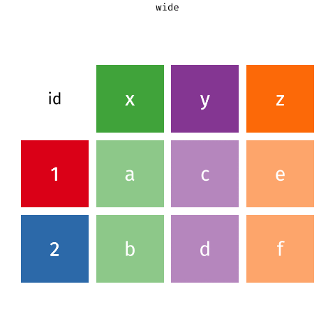

## Your Turn!

Is this data frame tidy? Why or why not? If not, use the appropriate pivot.

```r
billboard
```

```
## # A tibble: 317 × 79
##    artist     track date.entered   wk1   wk2   wk3   wk4   wk5   wk6   wk7   wk8
##    <chr>      <chr> <date>       <dbl> <dbl> <dbl> <dbl> <dbl> <dbl> <dbl> <dbl>
##  1 2 Pac      Baby… 2000-02-26      87    82    72    77    87    94    99    NA
##  2 2Ge+her    The … 2000-09-02      91    87    92    NA    NA    NA    NA    NA
##  3 3 Doors D… Kryp… 2000-04-08      81    70    68    67    66    57    54    53
##  4 3 Doors D… Loser 2000-10-21      76    76    72    69    67    65    55    59
##  5 504 Boyz   Wobb… 2000-04-15      57    34    25    17    17    31    36    49
##  6 98^0       Give… 2000-08-19      51    39    34    26    26    19     2     2
##  7 A*Teens    Danc… 2000-07-08      97    97    96    95   100    NA    NA    NA
##  8 Aaliyah    I Do… 2000-01-29      84    62    51    41    38    35    35    38
##  9 Aaliyah    Try … 2000-03-18      59    53    38    28    21    18    16    14
## 10 Adams, Yo… Open… 2000-08-26      76    76    74    69    68    67    61    58
## # ℹ 307 more rows
## # ℹ 68 more variables: wk9 <dbl>, wk10 <dbl>, wk11 <dbl>, wk12 <dbl>,
## #   wk13 <dbl>, wk14 <dbl>, wk15 <dbl>, wk16 <dbl>, wk17 <dbl>, wk18 <dbl>,
## #   wk19 <dbl>, wk20 <dbl>, wk21 <dbl>, wk22 <dbl>, wk23 <dbl>, wk24 <dbl>,
## #   wk25 <dbl>, wk26 <dbl>, wk27 <dbl>, wk28 <dbl>, wk29 <dbl>, wk30 <dbl>,
## #   wk31 <dbl>, wk32 <dbl>, wk33 <dbl>, wk34 <dbl>, wk35 <dbl>, wk36 <dbl>,
## #   wk37 <dbl>, wk38 <dbl>, wk39 <dbl>, wk40 <dbl>, wk41 <dbl>, wk42 <dbl>, …
```

## Desired Output

```
## # A tibble: 5,307 × 5
##    artist  track                   date.entered week   rank
##    <chr>   <chr>                   <date>       <chr> <dbl>
##  1 2 Pac   Baby Don't Cry (Keep... 2000-02-26   wk1      87
##  2 2 Pac   Baby Don't Cry (Keep... 2000-02-26   wk2      82
##  3 2 Pac   Baby Don't Cry (Keep... 2000-02-26   wk3      72
##  4 2 Pac   Baby Don't Cry (Keep... 2000-02-26   wk4      77
##  5 2 Pac   Baby Don't Cry (Keep... 2000-02-26   wk5      87
##  6 2 Pac   Baby Don't Cry (Keep... 2000-02-26   wk6      94
##  7 2 Pac   Baby Don't Cry (Keep... 2000-02-26   wk7      99
##  8 2Ge+her The Hardest Part Of ... 2000-09-02   wk1      91
##  9 2Ge+her The Hardest Part Of ... 2000-09-02   wk2      87
## 10 2Ge+her The Hardest Part Of ... 2000-09-02   wk3      92
## # ℹ 5,297 more rows
```

## Solution 1

```r
billboard |> pivot_longer(
  wk1:wk76,
  names_to = "week",
  values_to = "rank",
  values_drop_na = TRUE
  )
```

## Solution 2

```r
billboard |> pivot_longer(
  -c(artist, track, date.entered),
  names_to = "week",
  values_to = "rank",
  values_drop_na = TRUE
  )
```

## Separate Columns

Sometimes columns contain more than one data value. Use `separate()` to split those values into two (or more) columns.

```r
crm_long
```

```
## # A tibble: 126,372 × 4
##    region customer_id month_year transactions
##    <chr>        <dbl> <chr>             <dbl>
##  1 South         1001 jan_2018              1
##  2 South         1001 feb_2018              0
##  3 South         1001 mar_2018              0
##  4 South         1001 apr_2018              0
##  5 South         1001 may_2018              0
##  6 South         1001 jun_2018              4
##  7 South         1001 jul_2018              0
##  8 South         1001 aug_2018              0
##  9 South         1001 sep_2018              0
## 10 South         1001 oct_2018              0
## # ℹ 126,362 more rows
```

```r
crm_long <- crm_long |>
  separate(month_year, c("month", "year"), sep = "_")

crm_long
```

```
## # A tibble: 126,372 × 5
##    region customer_id month year  transactions
##    <chr>        <dbl> <chr> <chr>        <dbl>
##  1 South         1001 jan   2018             1
##  2 South         1001 feb   2018             0
##  3 South         1001 mar   2018             0
##  4 South         1001 apr   2018             0
##  5 South         1001 may   2018             0
##  6 South         1001 jun   2018             4
##  7 South         1001 jul   2018             0
##  8 South         1001 aug   2018             0
##  9 South         1001 sep   2018             0
## 10 South         1001 oct   2018             0
## # ℹ 126,362 more rows
```

Now we can summarize purchase activity for every region-month in 2018 and order the 48 combinations by average purchases per customer.

```r
crm_long |>
  group_by(month, region) |>
  summarize(
    total_transactions = sum(transactions),
    avg_transactions = mean(transactions),
    .groups = "drop"
  ) |>
  arrange(desc(avg_transactions))
```

```
## # A tibble: 48 × 4
##    month region    total_transactions avg_transactions
##    <chr> <chr>                  <dbl>            <dbl>
##  1 nov   South                   1812            1.63
##  2 dec   Midwest                 1723            1.56
##  3 dec   West                    7922            1.55
##  4 dec   Northeast               4928            1.53
##  5 dec   South                   1693            1.52
##  6 nov   West                    7656            1.50
##  7 nov   Northeast               4824            1.50
##  8 nov   Midwest                 1646            1.50
##  9 apr   Midwest                  751            0.682
## 10 may   South                    749            0.674
## # ℹ 38 more rows
```

## Unite Columns

When two (or more) values should be in one column, `unite()` the values into one column.

```r
crm_long |>
  unite("month_year", c(month, year), sep = "_")
```

```
## # A tibble: 126,372 × 4
##    region customer_id month_year transactions
##    <chr>        <dbl> <chr>             <dbl>
##  1 South         1001 jan_2018              1
##  2 South         1001 feb_2018              0
##  3 South         1001 mar_2018              0
##  4 South         1001 apr_2018              0
##  5 South         1001 may_2018              0
##  6 South         1001 jun_2018              4
##  7 South         1001 jul_2018              0
##  8 South         1001 aug_2018              0
##  9 South         1001 sep_2018              0
## 10 South         1001 oct_2018              0
## # ℹ 126,362 more rows
```

Of all the {tidyr} functions, `unite()` might seem the least useful. However, we really would like `month_year` to be an actual date. If we can add a day, we can use {lubridate} to create a date.

```r
crm_long <- crm_long |>
  mutate(day = 1) |>
  unite("date", c(day, month, year), sep = "-") |>
  mutate(date = dmy(date))

crm_long
```

```
## # A tibble: 126,372 × 4
##    region customer_id date       transactions
##    <chr>        <dbl> <date>            <dbl>
##  1 South         1001 2018-01-01            1
##  2 South         1001 2018-02-01            0
##  3 South         1001 2018-03-01            0
##  4 South         1001 2018-04-01            0
##  5 South         1001 2018-05-01            0
##  6 South         1001 2018-06-01            4
##  7 South         1001 2018-07-01            0
##  8 South         1001 2018-08-01            0
##  9 South         1001 2018-09-01            0
## 10 South         1001 2018-10-01            0
## # ℹ 126,362 more rows
```

With a long data frame and a `date` column, we can plot average monthly purchases per customer in each region.

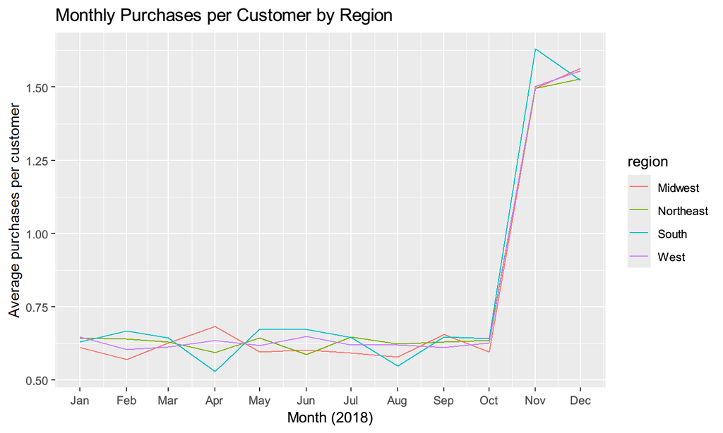

```r
crm_long |>
  group_by(date, region) |>
  summarize(
    total_transactions = sum(transactions),
    avg_transactions = mean(transactions),
    .groups = "drop"
  ) |>
  ggplot(aes(x = date, y = avg_transactions, color = region)) +
  geom_line() +
  scale_x_date(date_breaks = "month", date_labels = "%b") +
  labs(
    title = "Monthly Purchases per Customer by Region",
    x = "Month (2018)",
    y = "Average purchases per customer"
  )
```

## Data Types

We’ve been using **tibbles**, a modern form of **data frame**. Each column in a tibble (dataframe) is a vector. Dataframes can contain multiple columns with different types, but the elements **within a vector** share one data type, such as double, integer, or character.

For example: combining numbers and text with `c()` (a vector) **coerces** all values to characters:

```r
vector_example <- c(1, 2, "three")

vector_example
```

```
## [1] "1"     "2"     "three"
```

Data frames are nice to work with because each vector can be of a different data type.

```r
tibble(id = 1:3, state = "AZ")
```

```
## # A tibble: 3 × 2
##      id state
##   <int> <chr>
## 1     1 AZ
## 2     2 AZ
## 3     3 AZ
```

## Coercion

Sometimes we need to change an object’s form. For example, `as_tibble()` puts our example vector into a one-column tibble:

```r
as_tibble(vector_example)
```

```
## # A tibble: 3 × 1
##   value
##   <chr>
## 1 1
## 2 2
## 3 three
```

The column still contains the `character` type. Converting to a tibble does not recover the original numeric values. When would a table be more useful than a vector?

We can similarly coerce data types with `as.*()` functions (e.g., `as.numeric()` and `as.character()`).

## Your Turn!

Suppose you are building a ggplot visualization that shows the distributions of customer incomes for different zip codes. However, R is treating the values of zip code as a numeric value. Is this correct? If not, what data type might make more sense? Perform the appropriate coercion.

```r
zip_codes <- c(30301, 60614, 90210, 10001, 73301, 15213, 44101, 84101, 19104, 96815)

glimpse(zip_codes)
```

```
##  num [1:10] 30301 60614 90210 10001 73301 ...
```

## Desired Output

```
##  chr [1:10] "30301" "60614" "90210" "10001" "73301" "15213" "44101" "84101" ...
```

## Code Solution

```r
zip_codes <- as.character(zip_codes)

glimpse(zip_codes)
```

The `fct_*()` functions help create factors and manage the order of their levels. Here, the most common region comes first:

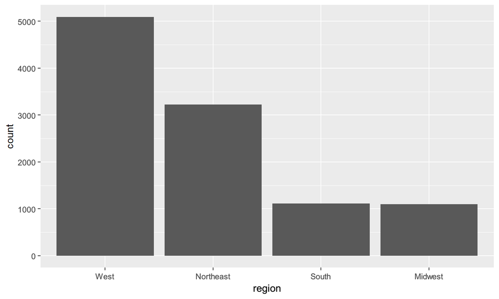

```r
crm_data |>
  mutate(region = fct_infreq(region)) |>
  ggplot(aes(x = region)) +
  geom_bar()
```

By default, `geom_bar()` counts observations at each x value using `stat_count()`. Use `geom_col()` when the bar heights have already been calculated, as in a table produced by `count()`.

We’ve used `fct_reorder()` to order factor levels by another variable. `fct_infreq()` orders levels by frequency; `fct_rev()` reverses their order. These functions change the category order used by the plot, not the row order.

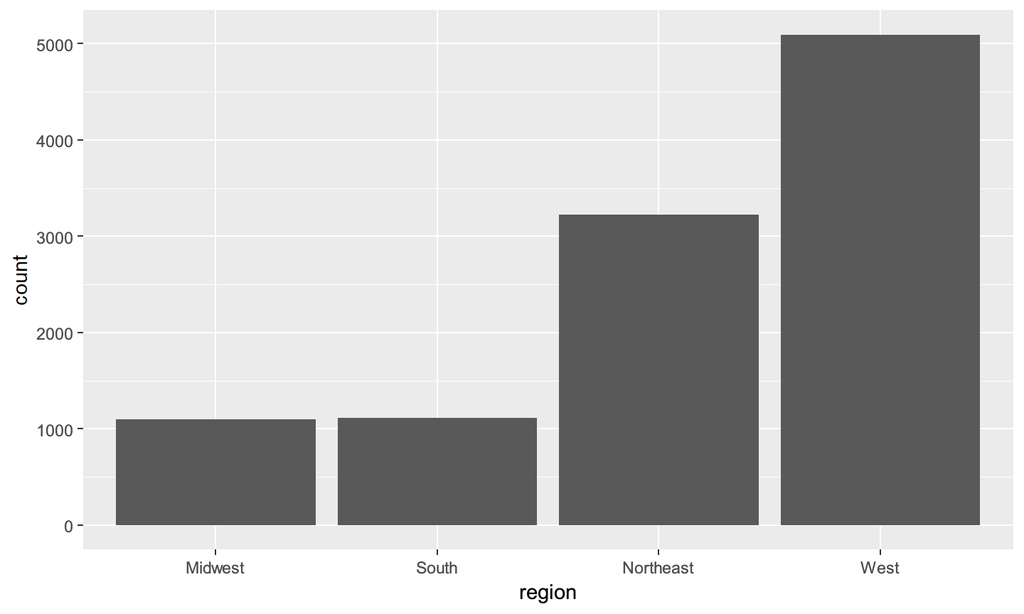

```r
crm_data |>
  mutate(region = region |> fct_infreq() |> fct_rev()) |>
  ggplot(aes(x = region)) +
  geom_bar()
```

## Live Coding Exercise

Patagonia wants a plot that tells a useful story about customer purchase activity over time using these historical records.

- Which measure and time period would be useful to the client?
- How should we interpret a change in purchase activity?
- Which assumptions or limitations could change our interpretation?

## Wrapping Up

*Summary*

- Discussed the philosophy of tidy data.
- Practiced {tidyr} functions for tidying data.
- Considered data classes, types, and coercion.

*Next Time*

- Querying databases.

*Supplementary Material*

- *R for Data Science (2e)*: [5 Data tidying](https://r4ds.hadley.nz/data-tidy.html) and [28 Quarto](https://r4ds.hadley.nz/quarto.html).

*Artwork by @allison_horst*

## Exercise 4: Recent and Frequent Customers

Patagonia wants to understand customers who purchased recently and those who purchased frequently before planning customer outreach.

Use `customer_data.csv` and `store_transactions.csv`. The files describe the same customers, identified by `customer_id`; monthly purchase counts run from January 2005 through December 2018. Treat December 2018 as the endpoint for evaluating activity.

Recency, frequency, and monetary value form an RFM analysis. These files support recency and frequency; purchase counts do not measure money spent.

## Exercise 4: The Client Report

- Define and justify a recent-customer group using purchase timing relative to the data endpoint. Choose your own recent window.
- Define and justify a frequent-customer group using purchase counts over a stated period. Choose your own threshold.
- For each group, report its size and include at least one demographic or financial summary or chart, with an interpretation of the customers’ profiles.
- Explain one limitation of using these historical groups for customer outreach. If you report age, state the reference year and that it is approximate.

## Exercise 4: Submit

Submit a Word document rendered from Quarto containing your definitions, code, results, and written interpretation. Decide which operations and sequence answer the client’s questions; different defensible approaches are welcome. The two customer groups may overlap.